# Basic Latin hypercube samples and designs with package lhs

Rob Carnell

2022-03-21

### Theory of Latin Hypercube Sampling

For the technical basis of Latin Hypercube Sampling (LHS) and Latin Hypercube Designs (LHD) please see: * Stein, Michael. *Large Sample Properties of Simulations Using Latin Hypercube Sampling* Technometrics, Vol 28, No 2, 1987. * McKay, MD, et.al. *A Comparison of Three Methods for Selecting Values of Input Variables in the Analysis of Output from a Computer Code* Technometrics, Vol 21, No 2, 1979.

This package was created to bring these designs to R and to implement many of the articles that followed on optimized sampling methods.

### Create a Simple LHS

Basic LHS’s are created using `randomLHS`.

```r
# set the seed for reproducibility
set.seed(1111)
# a design with 5 samples from 4 parameters
A <- randomLHS(5, 4)
A
```

```
#>           [,1]       [,2]      [,3]      [,4]
#> [1,] 0.6328827 0.48424369 0.1678234 0.1974741
#> [2,] 0.2124960 0.88111537 0.6069217 0.4771109
#> [3,] 0.1277885 0.64327868 0.3612360 0.9862456
#> [4,] 0.8935830 0.27182878 0.4335808 0.6052341
#> [5,] 0.5089423 0.02269382 0.8796676 0.2036678
```

In general, the LHS is uniform on the margins until transformed (Figure 1):

Figure 1. Two dimensions of a Uniform random LHS with 5 samples

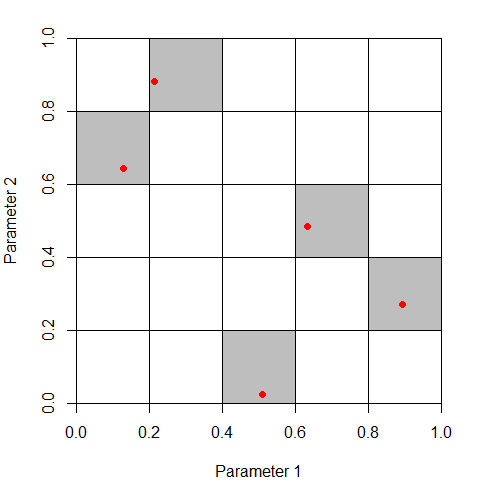

It is common to transform the margins of the design (the columns) into other distributions (Figure 2)

```r
B <- matrix(nrow = nrow(A), ncol = ncol(A))
B[,1] <- qnorm(A[,1], mean = 0, sd = 1)
B[,2] <- qlnorm(A[,2], meanlog = 0.5, sdlog = 1)
B[,3] <- A[,3]
B[,4] <- qunif(A[,4], min = 7, max = 10)
B
```

```
#>             [,1]      [,2]      [,3]     [,4]
#> [1,]  0.33949794 1.5848575 0.1678234 7.592422
#> [2,] -0.79779049 5.3686737 0.6069217 8.431333
#> [3,] -1.13690757 2.3803237 0.3612360 9.958737
#> [4,]  1.24581019 0.8982639 0.4335808 8.815702
#> [5,]  0.02241694 0.2228973 0.8796676 7.611003
```

Figure 2. Two dimensions of a transformed random LHS with 5 samples

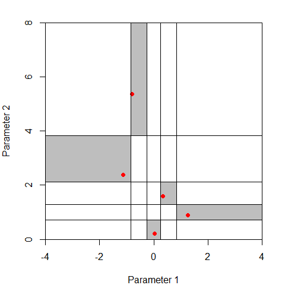

### Optimizing the Design

The LHS can be optimized using a number of methods in the `lhs` package. Each method attempts to improve on the random design by ensuring that the selected points are as uncorrelated and space filling as possible. Table 1 shows some results. Figure 3, Figure 4, and Figure 5 show corresponding plots.

```r
set.seed(101)
A <- randomLHS(30, 10)
A1 <- optimumLHS(30, 10, maxSweeps = 4, eps = 0.01)
A2 <- maximinLHS(30, 10, dup = 5)
A3 <- improvedLHS(30, 10, dup = 5)
A4 <- geneticLHS(30, 10, pop = 1000, gen = 8, pMut = 0.1, criterium = "S")
A5 <- geneticLHS(30, 10, pop = 1000, gen = 8, pMut = 0.1, criterium = "Maximin")
```

Table 1. Sample results and metrics of various LHS algorithms

| Method | Min Distance btwn pts | Mean Distance btwn pts | Max Correlation btwn pts |
| --- | --- | --- | --- |
| randomLHS | 0.6346585 | 1.2913235 | 0.5173006 |
| optimumLHS | 0.8717797 | 1.3001892 | 0.1268209 |
| maximinLHS | 0.595395 | 1.2835191 | 0.2983643 |
| improvedLHS | 0.6425673 | 1.2746711 | 0.5711527 |
| geneticLHS (S) | 0.8340751 | 1.3026543 | 0.3971539 |
| geneticLHS (Maximin) | 0.8105733 | 1.2933412 | 0.5605546 |

Figure 3. Pairwise margins of a randomLHS

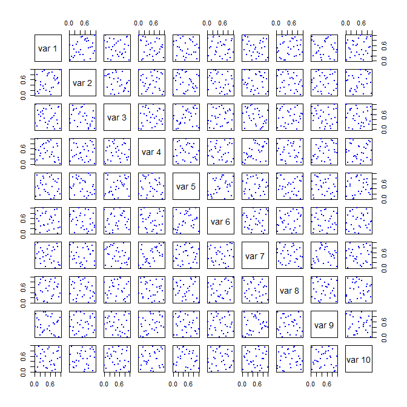

Figure 4. Pairwise margins of a optimumLHS

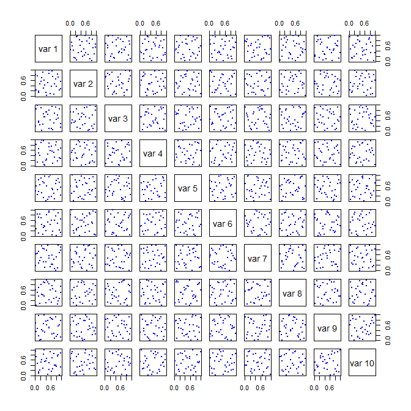

Figure 5. Pairwise margins of a maximinLHS

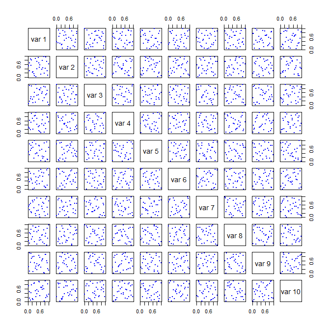